# Wagner_Lab3_CP1

Wagner Santos

21 de maio de 2018

##### Universidade Federal de Campina Grande

##### Fundamentos de Pesquisa em Ciência da Computação II

##### Problema 3 - Checkpoint 1: Inferência via ICs

### Introdução

Problema de exploração de dados que a Wikimedia Foundation usou em 2016 para recrutar pessoas para trabalhar no departamento de descoberta deles.

De fato, os dados de acesso a projetos da wikimedia que utilizamos no problema 2 são dados de uma amostra dos usuários, e não da população.

Sabendo disso, será produzido uma versão resumida do relatório que foi feito para o Lab 2, CP 4, que:

```
1. responde as 3 primeiras perguntas da tarefa original utilizando inferência estatística realizada através de intervalos de confiança e bootstrap.
  1. Qual é nossa taxa de click geral diária? Como ela varia entre os grupos?
  2. Qual resultados as pessoas tendem a tentar primeiro? Como ela muda dia a dia?
  3. Qual é nossa taxa de resultados zerados diária? Como ela varia entre os grupos?

2. testar o que acontece se para a pergunta 1, em vez de comparar o grupo A com o grupo B (um teste A/B), você compara metade das sessões do grupo A (escolhida aleatoriamente) com outra metade das sessões do mesmo grupo (um teste A/A).
```

### Definições

Nesta atividade o principal interesse está em medir a proporção de sessões de busca onde o usuário clica em um dos resultados apresentadoos, sendo representado através do “clickthrough rate”, como também na proporção de buscas que não tiveram resultados, sendo representada por “zero results rate”

Usaremos “bootstrap” e IC para inferir sobre a amostra utilizada pela Wikimedia, com base em um nível de confiança de 95%.

### Qual é nossa taxa de click geral diária? Como ela varia entre os grupos?

As taxas do grupo A foram maiores em relação ao grupo B.

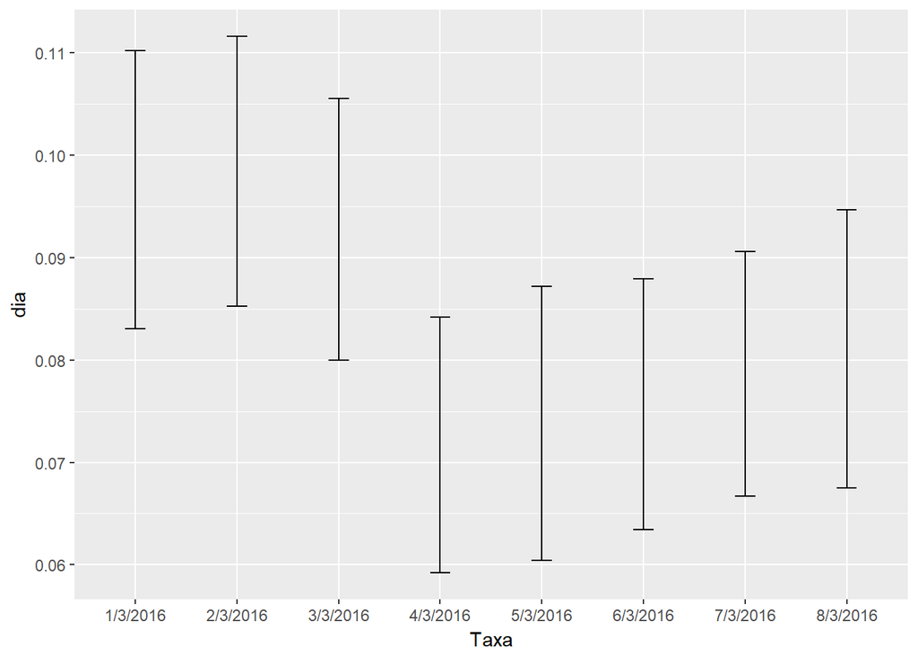

Como varia entre os grupos:

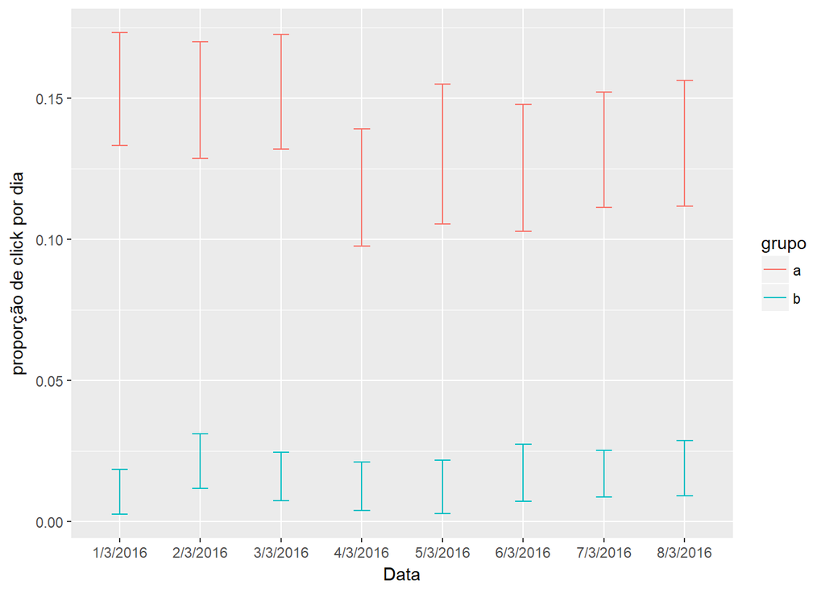

```r
cliques_por_dia_grupos <- sessoes %>%
    group_by(data, grupo) %>%
    summarise(boot = list(boot(com_clique, taxa_de_cliques, R = 1000)),
              ci = list(boot.ci(boot[[1]], conf = 0.95, type = "basic")),
              lim_inf = ci[[1]][[4]][4],
              lim_sup = ci[[1]][[4]][5]) %>%
    select(-c(boot, ci))

cliques_por_dia_grupos %>%
    ggplot(aes(x = data, ymin = lim_inf, ymax = lim_sup, color = grupo)) +
    geom_errorbar(width = .2) +
    labs(x = "Data", y = "proporção de click por dia")
```

### Quais resultados os usuários tendem a tentar primeiro? Como isso muda no dia-a-dia?

```r
total_click_occurrency <- buscas %>%
    na.omit(col = 'first_click') %>%
    group_by(first_click) %>%
    count(first_click)
head(total_click_occurrency,10)
```

```
## # A tibble: 10 x 2
## # Groups:   first_click [10]
##    first_click     n
##          <int> <int>
##  1           1   705
##  2           2   165
##  3           3    96
##  4           4    51
##  5           5    26
##  6           6    22
##  7           7    15
##  8           8    11
##  9           9    11
## 10          10     5
```

```r
tail(total_click_occurrency,10)
```

```
## # A tibble: 10 x 2
## # Groups:   first_click [10]
##    first_click     n
##          <int> <int>
##  1         105     1
##  2         126     1
##  3         141     1
##  4         143     1
##  5         163     1
##  6         168     1
##  7         169     1
##  8         223     2
##  9         380     1
## 10         469     1
```

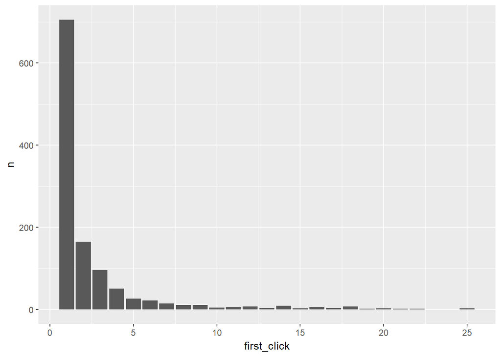

```r
first_click_occurrency <- buscas %>%
    na.omit(col = 'first_click') %>%
    filter(first_click <= 25) %>%
    group_by(first_click) %>%
    count(first_click)
ggplot(first_click_occurrency, aes(x=first_click, y=n)) + geom_bar(stat = 'identity')
```

### Qual é a taxa de resultados zero geral diária? Como ela varia entre os grupos A e B? Existe diferença significativa da taxa de resultados iguais a zero entre os grupos A e B?

```r
amostra3 = sample_n(buscas, 1000)

fun.boot <- function(dado, indices) {
  taxa_zero <- dado %>%
    slice(indices) %>%
    group_by(group, results) %>%
    summarise(n = n()) %>%
    mutate(taxa_zero = n / sum(n) * 100)  %>%
    ungroup()

  taxa_a <- taxa_zero %>%
    filter(results == 0, group == "a") %>%
    pull(taxa_zero)

  taxa_b <- taxa_zero %>%
    filter(results == 0, group == "b") %>%
    pull(taxa_zero)

  return(taxa_a - taxa_b)
}

res.boot <- boot(data = amostra3,
                 statistic = fun.boot,
                 R = 5000)

boot.ci(boot.out = res.boot, conf = 0.95, type = "basic")
```

```
## BOOTSTRAP CONFIDENCE INTERVAL CALCULATIONS
## Based on 5000 bootstrap replicates
##
## CALL :
## boot.ci(boot.out = res.boot, conf = 0.95, type = "basic")
##
## Intervals :
## Level      Basic
## 95%   (-7.940,  2.391 )
## Calculations and Intervals on Original Scale
```